# **Datamineo de onicofóros americanos, busqueda y patrones de distribución**

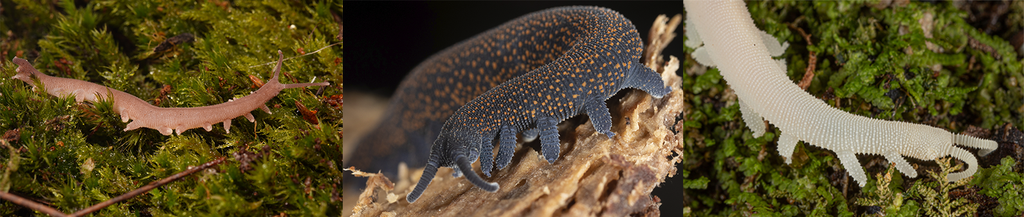

**Integrantes**:

- Daniel Sánchez González
- Joshua Ramsés Rodríguez Rodríguez
- Rebeca Quesada Céspedes

**Descripción del proyecto** Los onicóforos, conocidos por su alto endemismo, habitan en ambientes con elevados índices de humedad, lo que los hace particularmente vulnerables. Se realizó un análisis exploratorio de una base de datos utilizando el lenguaje de programación Python para determinar el estado del arte de los onicóforos en América.

**Justificación** Al iniciar el estudio de un grupo de organismos determinado, es necesario conocer sus áreas de distribución y las características de estos hábitats. Lo anterior, facilita identificar sitios con condiciones similares, con el objetivo de localizar nuevas poblaciones del grupo de interés. Contar con información base para el trabajo de este grupo zoológico, facilitará definir los posibles lugares de distribución.

**Antecedentes** El grupo de los onicóforos, también llamados gusanos aterciopelados, tienen una cubierta de quitina que los cubre (Johnson et al., 1969) y se caracterizan por ser de hábitos nocturnos debido al fototropismo negativo (Monge-Nájera, 1996).

Tienen además una baja densidad poblacional, lo que dificulta su observación (Jerez-Jaimes & Bernal-Pérez, 2009) y actualmente solo se encuentran en hábitats terrestres (Barquero-González, Cabrera, Valle-Cubero, Monge-Nájera & Morera-Brenes, 2016).

Debido a que no pueden controlar la pérdida de agua, suelen habitar en ambientes húmedos como bajo la hojarasca, dentro de troncos en descomposición, cerca de fuentes de agua o bajo rocas (Monge-Nájera y Hou, 1999).

Inicialmente en la literatura se reconocían dos familias: Peripatopsidae que se encuentran en Chile, Australia y el sur de África y Peripatidae que se ubican en América central, norte y sur, Antillas, África ecuatorial y el sureste de Asia (Bouvier, 1905, 1907; Ruhberg, 1985 y Monge-Nájera, 1995). A la fecha se conocen 6 familias: Hallucigeniidae, Helenodoridae, Luolishaniidae, Peripatidae, Peripatopsidae y Tertiapatidae.

En Costa Rica, según estudios recientes, los onicóforos se han encontrado en un rango altitudinal que varía desde los 85 hasta los 2000 msnm (Barquero-González et al., 2016). Este hallazgo resalta la diversidad de hábitats que estos organismos pueden ocupar en el país, lo cual hace indispensable la recopilación continua de datos sobre su distribución y ecología (Morera-Brenes & Monge-Nájera, 1990).

Afortunadamente, la tecnología ha facilitado el acceso a información científica a través de diversas plataformas globales de datos abiertos, las cuales permiten el registro y la consulta de información de manera gratuita (Arriagada-Benitez, 2020). Estas herramientas resultan cruciales para monitorear especies poco estudiadas como los onicóforos y para fomentar la investigación colaborativa (Lemuz-Delgado y Pérez, 2020). De esta forma, se crea una relación entre los onicóforos y la importancia de las plataformas de datos abiertos para su estudio(Álvarez y Coll-Serrano, 2018).

**Descripción del problema** Se requería conocer el estado del arte de onicóforos en el continente Americano, con especial atención para Costa Rica

**Objetivo** Determinar la distribución y diversidad de familias de onicóforos por país para el continente Americano

**Descripción de los datos a utilizar** Los datos que se utilizaron para este trabajo se descargaron de la base de datos de Global Biodiversity Information Facility (GBIF) para el grupo de onicóforos. Los datos contenían información como: identificador, reino, phylum, familia, género, especie, país, elevación, coordenadas, fecha del evento, entre otros

# **Preprocesamiento de base de datos**

Se eliminó de la base de datos original, las columnas que no eran de interés.

Se filtró los datos para mantener infromación de países que pertenecían al continente americano.

Se filtró también los datos que no tuevieran el valor de género para trabajar a ese nivel taxonómico.

# **Depuración de base de Datos**

**Importar** base de datos descargada de GBIF.org (14 septiembre 2024) GBIF Occurrence Download https://doi.org/10.15468/dl.q66sgz

```python
from google.colab import drive
drive.mount('/content/drive')

#importamos pandas
import pandas as pd

# Crear el DataFrame
register_ony = "/content/drive/MyDrive/Phyton /ony.csv"
register_ony = pd.read_csv(register_ony, delimiter=';')  #Ajustar separación por ';'
register_ony.head()
```

|  | gbifID | datasetKey | occurrenceID | kingdom | phylum | class | order | family | genus | species | ... | identifiedBy | dateIdentified | license | rightsHolder | recordedBy | typeStatus | establishmentMeans | lastInterpreted | mediaType | issue |
| --- | --- | --- | --- | --- | --- | --- | --- | --- | --- | --- | --- | --- | --- | --- | --- | --- | --- | --- | --- | --- | --- |
| 0 | 931028643 | 4bfac3ea-8763-4f4b-a71a-76a6f5f243d3 | MCZ:IZ:43401 | Animalia | Onychophora | NaN | NaN | Peripatidae | Oroperipatus | Oroperipatus peruvianus | ... | Gonzalo Giribet | 2016-10-05T00:00:00 | CC_BY_NC_4_0 | President and Fellows of Harvard College | Luis Espinasa | NaN | NaN | 2024-08-28T04:12:27.262Z | NaN | GEODETIC_DATUM_INVALID |
| 1 | 911958582 | 828ca1f8-f762-11e1-a439-00145eb45e9a | NaN | Animalia | Onychophora | NaN | NaN | Peripatidae | Heteroperipatus | Heteroperipatus engelhardi | ... | NaN | NaN | CC_BY_4_0 | NaN | NaN | PARATYPE | NaN | 2024-09-11T09:26:42.572Z | NaN | COORDINATE_ROUNDED |
| 2 | 899600711 | 85b1cfb6-f762-11e1-a439-00145eb45e9a | 4C4C5367-7030-48D9-BD01-42279617EBE8 | Animalia | Onychophora | NaN | NaN | NaN | NaN | NaN | ... | NaN | NaN | CC_BY_NC_4_0 | NaN | Slapcinsky, John | NaN | NaN | 2024-09-09T04:12:11.298Z | NaN | INSTITUTION_MATCH_FUZZY |
| 3 | 890192982 | 4bfac3ea-8763-4f4b-a71a-76a6f5f243d3 | MCZ:IZ:29204 | Animalia | Onychophora | NaN | NaN | Peripatopsidae | Peripatoides | Peripatoides aurorbis | ... | Caitlin M. Baker | 2021-01-01T00:00:00 | CC_BY_NC_4_0 | President and Fellows of Harvard College | Scott Bartlam, Rosa Fernández, Gonzalo Giribet | NaN | NaN | 2024-08-28T04:17:11.139Z | StillImage | TYPE_STATUS_INVALID |
| 4 | 890192973 | 4bfac3ea-8763-4f4b-a71a-76a6f5f243d3 | MCZ:IZ:29205 | Animalia | Onychophora | NaN | NaN | Peripatopsidae | Peripatoides | NaN | ... | Gonzalo Giribet | NaN | CC_BY_NC_4_0 | President and Fellows of Harvard College | Scott Bartlam, Rosa Fernández, Gonzalo Giribet | NaN | NaN | 2024-08-28T04:12:24.508Z | StillImage | TYPE_STATUS_INVALID |

5 rows × 50 columns

**Explorar** la base de datos y seleccionar aquellos que puender ser útiles para el objetivo de la investigación

```python
# Mostrar todos los nombres de las columnas
print(register_ony.columns)
```

```
Index(['gbifID', 'datasetKey', 'occurrenceID', 'kingdom', 'phylum', 'class',
       'order', 'family', 'genus', 'species', 'infraspecificEpithet',
       'taxonRank', 'scientificName', 'verbatimScientificName',
       'verbatimScientificNameAuthorship', 'countryCode', 'locality',
       'stateProvince', 'occurrenceStatus', 'individualCount',
       'publishingOrgKey', 'decimalLatitude', 'decimalLongitude',
       'coordinateUncertaintyInMeters', 'coordinatePrecision', 'elevation',
       'elevationAccuracy', 'depth', 'depthAccuracy', 'eventDate', 'day',
       'month', 'year', 'taxonKey', 'speciesKey', 'basisOfRecord',
       'institutionCode', 'collectionCode', 'catalogNumber', 'recordNumber',
       'identifiedBy', 'dateIdentified', 'license', 'rightsHolder',
       'recordedBy', 'typeStatus', 'establishmentMeans', 'lastInterpreted',
       'mediaType', 'issue'],
      dtype='object')
```

**Eliminar** columnas irrelevantes para el objetivo de estudio

```python
# Eliminar las columnas no deseadas
register_ony = register_ony.drop(columns=["occurrenceID", "kingdom", "phylum","mediaType", "typeStatus", "license", "class", "order", "infraspecificEpithet","depth","depthAccuracy","establishmentMeans", "identifiedBy", "license",
                                          "basisOfRecord", "institutionCode", "collectionCode", "datasetKey", "species", "taxonRank", "scientificName","verbatimScientificName","verbatimScientificNameAuthorship", "occurrenceStatus", "individualCount",
                                          "month", "day", "eventDate","taxonKey","issue", "publishingOrgKey","dateIdentified","rightsHolder","recordedBy","lastInterpreted","catalogNumber","recordNumber"])

# Verificar filtrado
register_ony.head()
```

|  | gbifID | family | genus | countryCode | locality | stateProvince | decimalLatitude | decimalLongitude | coordinateUncertaintyInMeters | coordinatePrecision | elevation | elevationAccuracy | year | speciesKey |
| --- | --- | --- | --- | --- | --- | --- | --- | --- | --- | --- | --- | --- | --- | --- |
| 0 | 931028643 | Peripatidae | Oroperipatus | EC | El Chato, on the surface | Galápagos | -0.672770 | -90.43117 | NaN | 0.00001 | NaN | NaN | 2014.0 | 2235489.0 |
| 1 | 911958582 | Peripatidae | Heteroperipatus | SV | Ostkegel des Vulkans San Vicente, Finca El Carmen | NaN | 13.612617 | -88.83615 | NaN | NaN | NaN | NaN | 1951.0 | 2235497.0 |
| 2 | 899600711 | NaN | NaN | ID | Obi Island, slopes along Laiwui River, 6 km SS... | Maluku Utara Province | -1.397110 | 127.64776 | NaN | NaN | NaN | NaN | 2008.0 | NaN |
| 3 | 890192982 | Peripatopsidae | Peripatoides | NZ | Waikato, Raglan, Te Toto Gorge | NaN | -37.841850 | 174.77342 | NaN | 0.00001 | 144.0 | 0.0 | 2014.0 | 4862402.0 |
| 4 | 890192973 | Peripatopsidae | Peripatoides | NZ | Waikato, Karapiro, Walsh family farm | NaN | -37.943360 | 175.63790 | NaN | 0.00001 | 173.0 | 0.0 | 2014.0 | NaN |

**Filtro** paises de América: Dado que la investigación se centro en onicoforos presentes en América se redujo la base de datos para solamente tomar encuenta los registros en paises americanos.

```python
#Seleccionar los datos de paises de America

AmeCoun = ["BR", "CA", "CL", "CO", "CR", "DO", "EC", "GT","GD", "GF", "GY", "HN","HT", "JM",
          "MS", "MX", "NI", "PA", "PE", "PR", "SR", "SV", "TT", "US", "VC", "VE", "VI"]

# Filtrar el DataFrame por los valores de la columna "countryCod"
register_ony_filtered = register_ony[register_ony["countryCode"].isin(AmeCoun)]

# Verificar filtrado
register_ony_filtered.head()
```

|  | gbifID | family | genus | countryCode | locality | stateProvince | decimalLatitude | decimalLongitude | coordinateUncertaintyInMeters | coordinatePrecision | elevation | elevationAccuracy | year | speciesKey |
| --- | --- | --- | --- | --- | --- | --- | --- | --- | --- | --- | --- | --- | --- | --- |
| 0 | 931028643 | Peripatidae | Oroperipatus | EC | El Chato, on the surface | Galápagos | -0.672770 | -90.43117 | NaN | 0.00001 | NaN | NaN | 2014.0 | 2235489.0 |
| 1 | 911958582 | Peripatidae | Heteroperipatus | SV | Ostkegel des Vulkans San Vicente, Finca El Carmen | NaN | 13.612617 | -88.83615 | NaN | NaN | NaN | NaN | 1951.0 | 2235497.0 |
| 9 | 872993215 | Peripatidae | Epiperipatus | BR | Manaus, Reserva Ducke | Amazonas | -2.929540 | -59.97556 | NaN | 0.00001 | NaN | NaN | 2013.0 | NaN |
| 11 | 729719797 | Peripatidae | Peripatus | NI | Great Corn Island | NaN | 12.170650 | -83.05437 | 1900.0 | 0.00001 | NaN | NaN | 1966.0 | NaN |
| 12 | 727587425 | Peripatopsidae | Metaperipatus | CL | forest near Lago Tinquilco (Región IX, Araucanía) | NaN | -39.150000 | -71.70000 | NaN | 0.00001 | 815.0 | 0.0 | 2004.0 | 2235585.0 |

**Eliminar** los datos con **faltantes** en la columna "genus"

```python
# Eliminar las filas que tengan NaN en la columna "genus"
register_ony_filtered = register_ony_filtered.dropna(subset=["genus"])

# Mostrar las primeras filas del DataFrame después de eliminar los NaN en "genus"
register_ony_filtered.head()
```

|  | gbifID | family | genus | countryCode | locality | stateProvince | decimalLatitude | decimalLongitude | coordinateUncertaintyInMeters | coordinatePrecision | elevation | elevationAccuracy | year | speciesKey |
| --- | --- | --- | --- | --- | --- | --- | --- | --- | --- | --- | --- | --- | --- | --- |
| 0 | 931028643 | Peripatidae | Oroperipatus | EC | El Chato, on the surface | Galápagos | -0.672770 | -90.43117 | NaN | 0.00001 | NaN | NaN | 2014.0 | 2235489.0 |
| 1 | 911958582 | Peripatidae | Heteroperipatus | SV | Ostkegel des Vulkans San Vicente, Finca El Carmen | NaN | 13.612617 | -88.83615 | NaN | NaN | NaN | NaN | 1951.0 | 2235497.0 |
| 9 | 872993215 | Peripatidae | Epiperipatus | BR | Manaus, Reserva Ducke | Amazonas | -2.929540 | -59.97556 | NaN | 0.00001 | NaN | NaN | 2013.0 | NaN |
| 11 | 729719797 | Peripatidae | Peripatus | NI | Great Corn Island | NaN | 12.170650 | -83.05437 | 1900.0 | 0.00001 | NaN | NaN | 1966.0 | NaN |
| 12 | 727587425 | Peripatopsidae | Metaperipatus | CL | forest near Lago Tinquilco (Región IX, Araucanía) | NaN | -39.150000 | -71.70000 | NaN | 0.00001 | 815.0 | 0.0 | 2004.0 | 2235585.0 |

## **Datos estadisticos y visualización**

Registro de datos durante 155 años en la región de America. Trinidad y Tobago contabilizó 69 registros, seguido de Costa Rica con 46 individuos y México con 42 (Fig. #1). En Estados Unidos se reportaron 39 individuos, mientras que Colombia registró 35 y Ecuador 32. Panamá contó con 22 registros y Jamaica con 21 individuos. Los demás países no superaron los 20 registros de onicóforos.

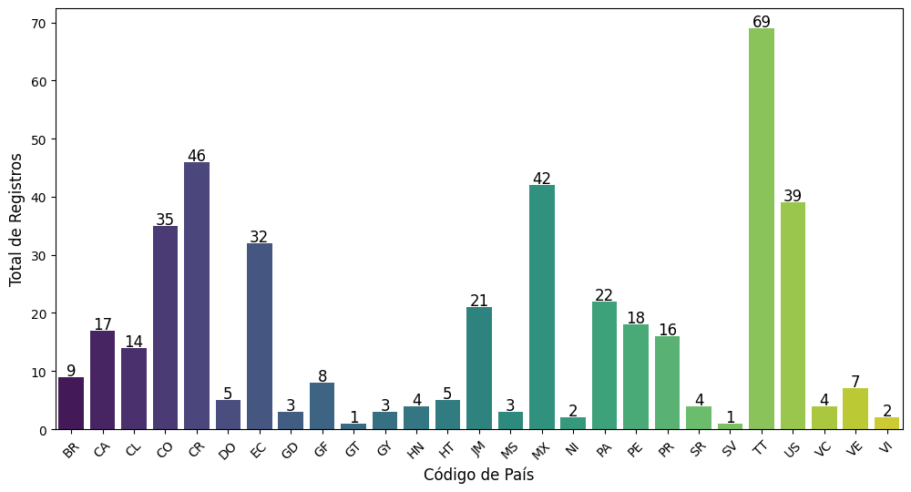

```
El país con mayor cantidad de registros de onicóforos es: TT con 69 registros.
```

```python
import matplotlib.pyplot as plt
import seaborn as sns

# Contar el número de registros de onicóforos por país
registro_por_pais = register_ony_filtered.groupby("countryCode").size().reset_index(name="total_registros")

# Encontrar el país con el mayor número de registros
pais_mayor_registros = registro_por_pais.loc[registro_por_pais["total_registros"].idxmax()]

# Crear un gráfico de barras
plt.figure(figsize=(12, 6))
bar_plot = sns.barplot(data=registro_por_pais, x="countryCode", y="total_registros", palette="viridis", hue="countryCode", legend=False)

# Añadir títulos y etiquetas
plt.xlabel("Código de País", fontsize=12)
plt.ylabel("Total de Registros", fontsize=12)

# Añadir los valores encima de las barras
for p in bar_plot.patches:
    bar_plot.annotate(format(int(p.get_height())),
                       (p.get_x() + p.get_width() / 2., p.get_height()),
                       ha='center', va='center',
                       fontsize=12, color='black',
                       xytext=(0, 5),  # Desplazamiento hacia arriba
                       textcoords='offset points')

# Mostrar el gráfico
plt.xticks(rotation=45)  # Disposición en el eje x
plt.show()

print(f"El país con mayor cantidad de registros de onicóforos es: {pais_mayor_registros['countryCode']} con {pais_mayor_registros['total_registros']} registros.")
```

**Fig 1**. Barplot de los registros en cada pais desde 1869 hasta 2024 en América. BR = Brasil, CA = Canadá, CL = Chile, CO = Colombia, CR = Costa Rica, DO = República Dominicana, EC = Ecuador, GD = Granada, GF = Guayana Francesa, GT= Guatemala, GY = Guyana, HN= Honduras, HT = Haití, JM = Jamaica, MS = Montserrat, MX = México, NI = Nicaragua, PA = Panamá, PE = Perú, PR = Puerto Rico, SR = Surinam, SV = El Salvador, TT = Trinidad y Tobago, US = Estados Unidos, VC = San Vicente y las Granadinas, VE = Venezuela, VI = Islas Vírgenes

**Heatmap** para visualizar la comparativa entre Year vs Country

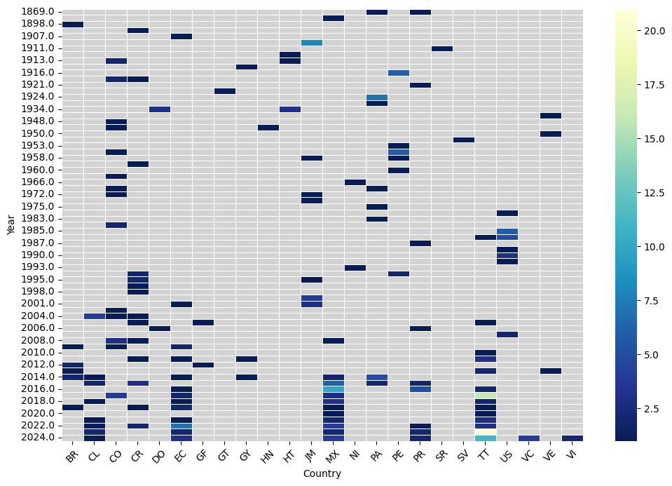

```python
import pandas as pd
import matplotlib.pyplot as plt

# Agrupar los datos por "year" y "countryCode" y contar la cantidad de ocurrencias
data_grouped = register_ony_filtered.groupby(["year", "countryCode"]).size().reset_index(name="count")

# Crear una tabla pivote para organizar los datos en el formato adecuado para el heatmap
heatmap_data = data_grouped.pivot(index="year", columns="countryCode", values="count")

# Definir un nuevo colormap con gris para NaN
cmap = sns.color_palette("YlGnBu", as_cmap=True).reversed()  # Invertir la escala de colores
cmap.set_bad('lightgrey')  # Establecer gris para NaN

# Crear el heatmap con el colormap modificado
plt.figure(figsize=(12, 8))
sns.heatmap(heatmap_data, cmap=cmap, fmt=".0f", linewidths=.5)

# Añadir títulos y etiquetas
plt.xlabel("Country")
plt.ylabel("Year")
plt.xticks(rotation=45)

# Mostrar el gráfico
plt.show()
```

**Fig 2**. Heatmap de los registro por año en cada pais de América con onicoforos reportados en GBIF. BR = Brasil, CA = Canadá, CL = Chile, CO = Colombia, CR = Costa Rica, DO = República Dominicana, EC = Ecuador, GD = Granada, GF = Guayana Francesa, GT= Guatemala, GY = Guyana, HN= Honduras, HT = Haití, JM = Jamaica, MS = Montserrat, MX = México, NI = Nicaragua, PA = Panamá, PE = Perú, PR = Puerto Rico, SR = Surinam, SV = El Salvador, TT = Trinidad y Tobago, US = Estados Unidos, VC = San Vicente y las Granadinas, VE = Venezuela, VI = Islas Vírgenes

## **Observaciones por género en América**

**Porcentaje** de registros por **genero** en el continente, se observo que *Oroperipatus* tiene la mayor cantidad de avistamientos, con un 22.9%, seguido de *Epiperipatus* con un 22.7% y *Peripatus* con un 14.8%. *Macroperipatus* representa el 14.4% de los registros, mientras que *Acinocricus* alcanza el 8.3%. El género *Principapillatus* tiene un 5.1%, *Hallucigenia* un 3.7%, y *Metaperipatus* un 2.8%. *Plicatoperipatus* cuenta con el 1.6% de los registros y *Mongeperipatus* con un 1.4%. Finalmente, el 2.3% corresponde a individuos que pertenencen a genéros que representan menos del 1% del total de registros.

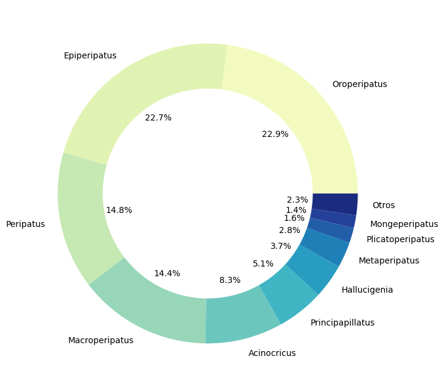

```python
# Contar las ocurrencias de cada género y calcular los porcentajes
genus_counts = register_ony_filtered['genus'].value_counts(normalize=True) * 100

# Agrupar los géneros menores al 1% como "Otros"
other_threshold = 1
other_count = genus_counts[genus_counts < other_threshold].sum()
genus_counts = genus_counts[genus_counts >= other_threshold]
genus_counts['Otros'] = other_count

# Paleta de colores
colors = sns.color_palette("YlGnBu", len(genus_counts))

# Crear un gráfico de pastel
plt.figure(figsize=(8, 8))
wedges, texts, autotexts = plt.pie(genus_counts, labels=genus_counts.index, autopct='%1.1f%%', colors=colors)

# Transformar en donut
centre_circle = plt.Circle((0, 0), 0.70, fc='white')  # El radio para ajustar centro de la dona
fig = plt.gcf()  # Obtiene la figura actual
ax = fig.gca()  # Obtiene el eje actual
ax.add_artist(centre_circle)  # Añade el círculo al eje actual

# Ajuste del tamaño de los porcentajes
plt.setp(autotexts, size=10)

plt.show()
```

**Fig 3**. Porcentaje de cada genero en el registro historico de América

**País** del continente con **mayor numero** de **géneros** reportados

```python
# Contabilizar el número de géneros únicos por país
genus_country = register_ony_filtered.groupby("countryCode")["genus"].nunique().reset_index(name="num_genus")
# Mostrar el resultado
print(genus_country)
```

```
   countryCode  num_genus
0           BR          3
1           CA          2
2           CL          2
3           CO          4
4           CR          4
5           DO          2
6           EC          1
7           GD          1
8           GF          2
9           GT          1
10          GY          2
11          HN          2
12          HT          1
13          JM          4
14          MS          1
15          MX          2
16          NI          2
17          PA          4
18          PE          1
19          PR          1
20          SR          2
21          SV          1
22          TT          3
23          US          2
24          VC          1
25          VE          3
26          VI          1
```

**Colombia**, **Costa Rica**, **Jamaica** y **Panamá** son los países que han reportado la mayor **variedad de géneros de onicóforo**s en su territorio, con un total de **4** de los **16** géneros conocidos en el continente.

**Genero** más **frecuente** por pais

```python
# Agrupar país x género, y contar los registros
genus_counts = register_ony_filtered.groupby(["countryCode", "genus"]).size().reset_index(name="count")

# Género más frecuente por país
most_frequent_genus = genus_counts.loc[genus_counts.groupby("countryCode")["count"].idxmax()]

print(most_frequent_genus)
```

```
   countryCode             genus  count
0           BR      Epiperipatus      7
3           CA      Hallucigenia     16
5           CL     Metaperipatus     12
7           CO      Epiperipatus     19
14          CR  Principapillatus     22
15          DO         Peripatus      4
17          EC      Oroperipatus     32
18          GD      Epiperipatus      3
19          GF      Epiperipatus      5
21          GT      Epiperipatus      1
23          GY         Peripatus      2
24          HN      Epiperipatus      3
26          HT         Peripatus      5
28          JM         Peripatus     11
31          MS         Peripatus      3
32          MX      Oroperipatus     41
34          NI      Oroperipatus      1
36          PA      Epiperipatus     19
40          PE      Oroperipatus     18
41          PR         Peripatus     16
42          SR      Epiperipatus      3
44          SV   Heteroperipatus      1
46          TT    Macroperipatus     48
48          US       Acinocricus     36
50          VC         Peripatus      4
53          VE         Peripatus      4
54          VI         Peripatus      2
```

**Visualización** de los registros historicos por **genero** en cada país de la lista.

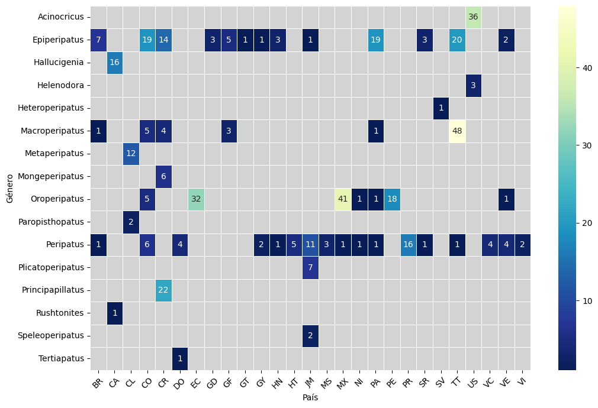

```python
# Lista de géneros
genuslist = [
    "Acinocricus", "Epiperipatus", "Hallucigenia", "Helenodora",
    "Heteroperipatus", "Macroperipatus", "Metaperipatus", "Mongeperipatus",
    "Oroperipatus", "Paropisthopatus", "Peripatus", "Plicatoperipatus",
    "Principapillatus", "Rushtonites", "Speleoperipatus", "Tertiapatus"
]

# Filtrar por género
register_ony_filtered = register_ony_filtered[register_ony_filtered["genus"].isin(genuslist)]

# Agrupar los datos por genus x countryCode y contar los registro
data_grouped = register_ony_filtered.groupby(["genus", "countryCode"]).size().reset_index(name="count")

# Crear una tabla para organizar los datos para el heatmap
heatmap_data = data_grouped.pivot(index="genus", columns="countryCode", values="count")

# Dimensiones el heatmap
plt.figure(figsize=(12, 8))

# Definir un nuevo colormap con gris para NaN
cmap = sns.color_palette("YlGnBu", as_cmap=True).reversed()  # Invertir la escala de colores
cmap.set_bad('lightgrey')  # Establecer gris para NaN

# Crear el heatmap
sns.heatmap(heatmap_data, cmap=cmap, fmt=".0f", linewidths=.5, annot=True, cbar=True)

# Añadir títulos y etiquetas
plt.xlabel("País")
plt.ylabel("Género")
plt.xticks(rotation=45)

# Mostrar el gráfico
plt.show()
```

**Fig 4**. Heatmap de los registros historicos por género de onicóforo en cada pais de América. BR = Brasil, CA = Canadá, CL = Chile, CO = Colombia, CR = Costa Rica, DO = República Dominicana, EC = Ecuador, GD = Granada, GF = Guayana Francesa, GT= Guatemala, GY = Guyana, HN= Honduras, HT = Haití, JM = Jamaica, MS = Montserrat, MX = México, NI = Nicaragua, PA = Panamá, PE = Perú, PR = Puerto Rico, SR = Surinam, SV = El Salvador, TT = Trinidad y Tobago, US = Estados Unidos, VC = San Vicente y las Granadinas, VE = Venezuela, VI = Islas Vírgenes

# **Correlación entre elevación y distribución de géneros**

Para buscar una **correlación** estadísticamente significativa entre los registros de elevación y género, se evaluó la **normalidad** de los datos (Shapiro) y se aplicó una prueba de **Kruskal-Wallis**.

```
Estadístico de Shapiro-Wilk: 0.8092438628390688
Valor p: 3.045179577661006e-09
Se rechaza la hipótesis nula: Los datos no siguen una distribución normal.
Estadístico H de Kruskal-Wallis: 15.273870755339363
Valor p: 0.018230294199040525
```

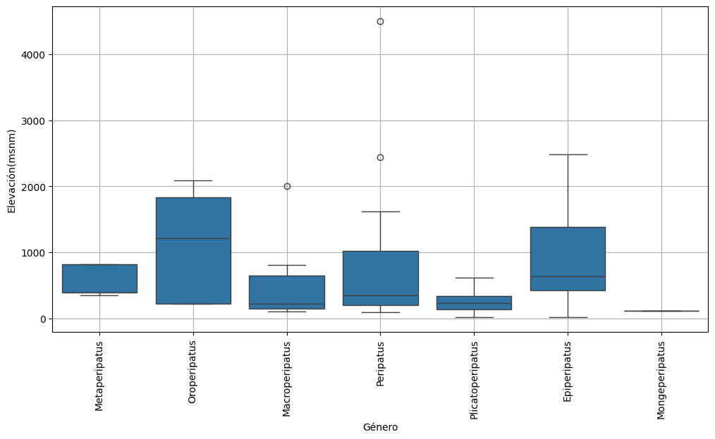

```python
# Cargar paquete para prueba de Shapiro
from scipy.stats import shapiro

# Filtrar para eliminar filas con faltante de información en la columna "elevation"
register_ony_filtered = register_ony_filtered.dropna(subset=["elevation"])

# Extraer los datos de la columna "elevation"
elevation_data = register_ony_filtered['elevation'].dropna()

# Realizar la prueba de Shapiro
stat, p_value = shapiro(elevation_data)

# Mostrar los resultados
print(f'Estadístico de Shapiro-Wilk: {stat}')
print(f'Valor p: {p_value}')

# Interpretación del resultado
if p_value > 0.05:
    print("No se rechaza la hipótesis nula: Los datos parecen seguir una distribución normal.")
else:
    print("Se rechaza la hipótesis nula: Los datos no siguen una distribución normal.")

#Cargar paquete para prueba de Kruskal

from scipy.stats import kruskal

# Agrupar los datos por género y extraer las elevaciones
groups = [group['elevation'].values for name, group in register_ony_filtered.groupby('genus')]

# Realizar la prueba de Kruskal-Wallis
kruskal_resultado = kruskal(*groups)

# Mostrar el resultado de la prueba
print(f'Estadístico H de Kruskal-Wallis: {kruskal_resultado.statistic}')
print(f'Valor p: {kruskal_resultado.pvalue}')

# Crear un boxplot para visualizar la relación entre género y elevación
plt.figure(figsize=(12, 6))
sns.boxplot(data=register_ony_filtered, x='genus', y='elevation')
plt.xticks(rotation=90)
plt.xlabel('Género')
plt.ylabel('Elevación(msnm)')
plt.grid(True)
plt.show()
```

**Fig 5**. Boxplot de la distribución de los género según la elevación reportada en América.

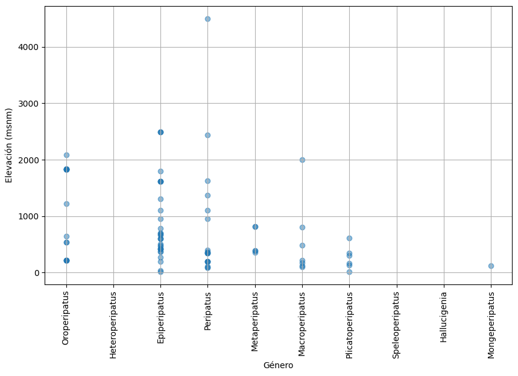

```python
# Dimenciones de la figura
plt.figure(figsize=(10, 6))

# Grafico de disperción entre el género y la elevación
plt.scatter(register_ony_filtered['genus'], register_ony_filtered['elevation'], alpha=0.5)

# Añadir etiquetas y título
plt.xlabel('Género')
plt.ylabel('Elevación (msnm)')

# Rotar las etiquetas del eje X
plt.xticks(rotation=90)

# Añadir una cuadrícula al gráfico
plt.grid(True)

# Mostrar el gráfico
plt.show()
```

**Fig 6**.Gráfico de dispersión de los rangos de distribución de los género según la elevación reportada en América.

# **Datos geoespaciales**

## Mapa de la distribución historica de onicóforos en el continente americano

Importar datos geoespaciales: La última versión de geopanda no contiene la información de continentes, por lo tanto, se importaron de manera local descargando la base de datos de https://www.naturalearthdata.com/downloads/110m-cultural-vectors/

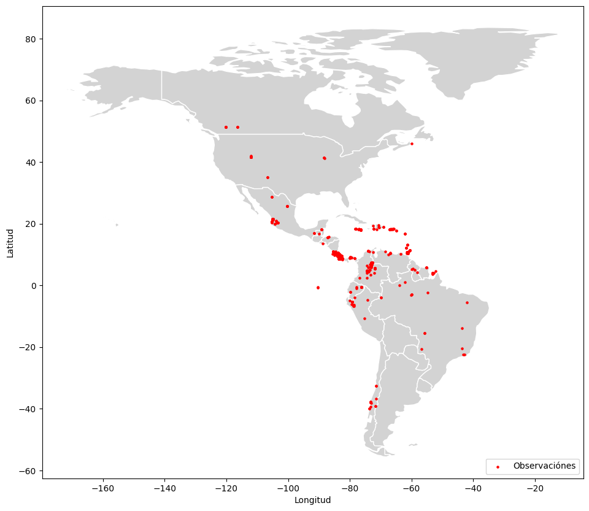

```python
import matplotlib.pyplot as plt
import geopandas as gpd

# Ruta a los archivos del continente
shapefile_path2 = "/content/drive/MyDrive/Phyton /ne_110m_admin_0_countries.shp"

# Ruta a los archivos de resgistro de onicoforos
shapefile_path1 = "/content/drive/MyDrive/Phyton /oni.shx"

# Importar el shapefile que contine las observaciones
gdf1 = gpd.read_file(shapefile_path1)

# Importar el shapefile countries
world = gpd.read_file(shapefile_path2)

# Filtrar por Norteamérica y Sudamérica
NA = world[world['CONTINENT'] == 'North America']
SA = world[world['CONTINENT'] == 'South America']

# Concatenar ambos DataFrames
america = pd.concat([NA, SA])

# Graficar el mapa
fig, ax = plt.subplots(figsize=(12, 10))
america.plot(ax=ax, color='lightgrey', edgecolor='white')
gdf1.plot(ax=ax, color='red', marker='o', markersize=5)
plt.xlabel("Longitud")
plt.ylabel("Latitud")

plt.legend(["Observaciónes"], loc='lower right')
```

**Fig 7**. Distribución de onicóforos en América registrados entre 1869 y 2024.

A nivel del continente, los onicóforos se distribuyen en gran parte de la región, con una mayor densidad en la zona ecuatorial y disminuyendo su presencia en los extremos de América del Norte y Sur. Además, se evidencian la ausencia de registros en varios países.

# **Costa Rica**

Para detallar la distribución de los onicórofos en nuestra país, se hizo una exploración de datos los registros disponibles en GBIF. Además se importó el shapefile de Costa Rica, descargado del link https://gadm.org/download_country.htm, para mejorar la fidelidad visual del polígono. Además, se importó nuevamente la base de datos (ony.csv) para evitar un sesgo en los datos por los filtrados anteriores.

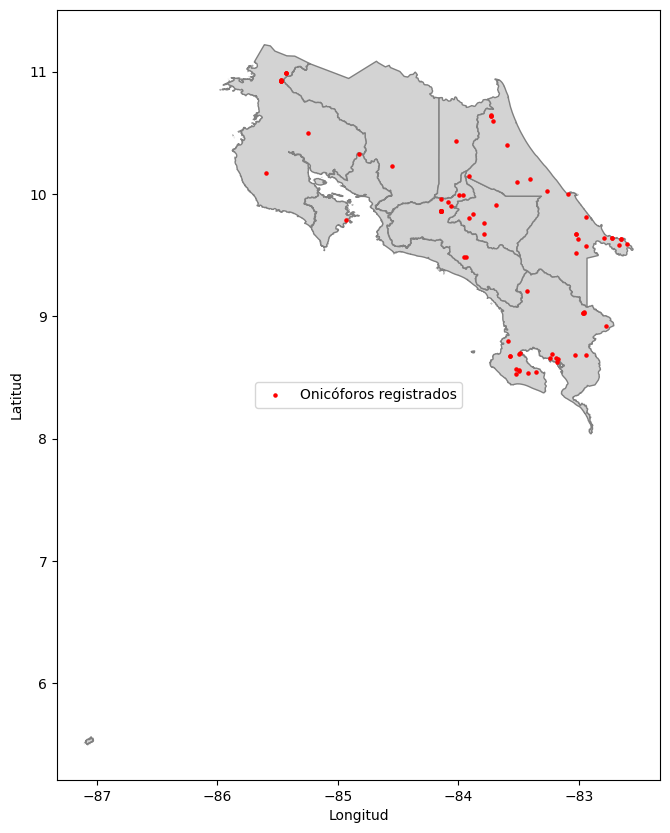

```python
# Importar shapefile de Costa Rica
shapefile_CR = '/content/drive/MyDrive/Phyton /gadm41_CRI_1.shp'

# Cargar el archivo .shp en un GeoDataFrame
gdf_map = gpd.read_file(shapefile_CR)

# Crear el DataFrame
register_CR_path = "/content/drive/MyDrive/Phyton /ony.csv"
register_CR = pd.read_csv(register_CR_path, delimiter=';')

# Filtrar los registros de CR
register_CR2= register_CR[register_CR['countryCode'] == 'CR']

# Convertir el DataFrame filtrado a un GeoDataFrame
gdf_CR = gpd.GeoDataFrame(
    register_CR2,
    geometry=gpd.points_from_xy(register_CR2['decimalLongitude'], register_CR2['decimalLatitude']),
    crs="EPSG:4326"  # Sistema de coordenadas WGS 84
)

# Graficar el mapa
fig, ax = plt.subplots(figsize=(12, 10))
gdf_map.plot(ax=ax, color='lightgrey', edgecolor='grey')

# Graficar los registros de onicóforos
gdf_CR.plot(ax=ax, color='red', marker='o', markersize=5, label='Onicóforos registrados')
plt.xlabel("Longitud")
plt.ylabel("Latitud")
plt.legend(loc='center')

# Mostrar el gráfico
plt.show()
```

**Fig 8.** Distribución del registro historico total en el territorio nacional desde 1902 hasta 2022.

Para facilitar la visualización de la distribución de los géneros y buscar posibles patrones se elaboró un segundo mapa con identificadores para cada género y para los datos que no contaban con esta descripción.

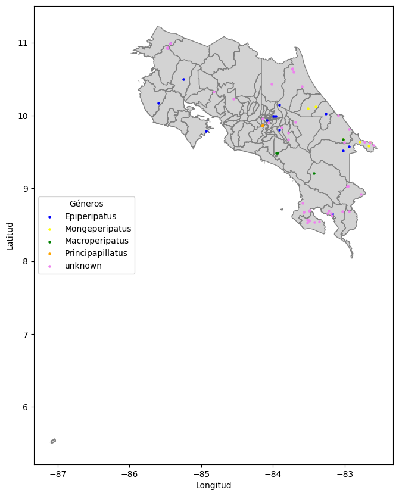

```python
# Importar shapefile de Costa Rica
shapefile_CR = '/content/drive/MyDrive/Phyton /gadm41_CRI_2.shp'

# Cargar el archivo .shp en un GeoDataFrame
gdf_map = gpd.read_file(shapefile_CR)

# Crear el DataFrame
register_CR_path = "/content/drive/MyDrive/Phyton /ony.csv"
register_CR = pd.read_csv(register_CR_path, delimiter=';')

# Filtrar los registros de CR
register_CR2 = register_CR[register_CR['countryCode'] == 'CR']

# Sustituir los valores faltantes en la columna 'genus' con 'unknown'
register_CR2.loc[:, 'genus'] = register_CR2['genus'].fillna('unknown')

# Convertir register_CR2 a un GeoDataFrame
gdf_CR = gpd.GeoDataFrame(
    register_CR2,
    geometry=gpd.points_from_xy(register_CR2['decimalLongitude'], register_CR2['decimalLatitude']),
    crs="EPSG:4326"  # Sistema de coordenadas WGS 84
)

# Lista de géneros y grupo 'unknown'
genera_list = ['Epiperipatus', 'Mongeperipatus', 'Macroperipatus', 'Principapillatus', 'unknown']

# Colores para los puntos de cada género
color_list = ['blue', 'yellow', 'green', 'orange', 'violet']

# Crear un diccionario para mapear cada género y su color
color_dict = dict(zip(genera_list, color_list))

# Graficar el mapa
fig, ax = plt.subplots(figsize=(12, 10))
gdf_map.plot(ax=ax, color='lightgrey', edgecolor='grey')

# Graficar los géneros registrados con colores
for genus in genera_list:
    subset = gdf_CR[gdf_CR['genus'] == genus]
    if not subset.empty:  # Asegurarse de que haya datos para el género
        subset.plot(ax=ax, color=color_dict[genus], marker='o', markersize=5, label=genus)
plt.xlabel("Longitud")
plt.ylabel("Latitud")
plt.legend(loc='center left', title='Géneros')

# Mostrar el gráfico
plt.show()
```

**Fig 9**. Distribución de los generos en el territorio nacional desde 1902 hasta 2022.

Los onicóforos reportados en el país, se distribuyen por todo el área, sin zonas específicas.

Se observó que, de un total de 106 registros en Costa Rica, 60 carecían de información sobre el género, lo que representa un 56.60% de los registro. El género con mayor cantidad de reportes fue *Principapillatus*, con 22 registros en el país (todos sin fecha), mientras que *Epiperipatus* conto con 14 registros, *Mongeperipatus* con 6 registros y por último *Macroperipatus* unicamente cuenta 4 registros para el país de Costa Rica (Fig 10).

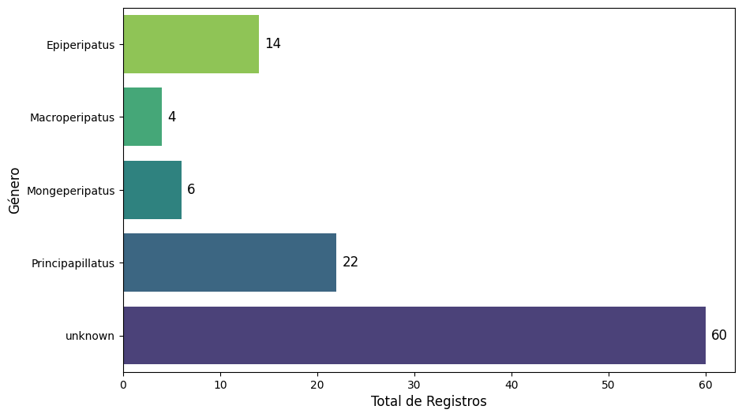

```python
# Asignar "unknown" a los registros que no tienen género
register_CR2.loc[:, 'genus'] = register_CR2['genus'].fillna('unknown')

# Contar el número de registros por género
registro_por_genero = register_CR2.groupby("genus").size().reset_index(name="total_registros")

# Crear un gráfico de barras
plt.figure(figsize=(10, 6))
bar_plot = sns.barplot(data=registro_por_genero, y="genus", x="total_registros", palette="viridis_r", hue="genus", legend=False)

# Añadir títulos y etiquetas
plt.ylabel("Género", fontsize=12)
plt.xlabel("Total de Registros", fontsize=12)

# Añadir los valores al lado de las barras
for p in bar_plot.patches:
    bar_plot.annotate(format(int(p.get_width())),
                      (p.get_width(), p.get_y() + p.get_height() / 2.),
                      ha='left', va='center',
                      fontsize=12, color='black',
                      xytext=(5, 0),textcoords='offset points')

# Mostrar el gráfico
plt.show()
```

**Fig 10**. Total de registros por género para Costa Rica